# Intro to Visulization: Univariate and Multivariate Graphs

Author

Gargee Shah

Published

March 18, 2023

## Setup

If you have not installed the following packages, please install them before loading them.

```r
library(tidyverse)
library(readxl)
library(haven) #for loading other datafiles (SAS, STATA, SPSS, etc.)
library(stringr) # if you have not installed this package, please install it.
library(ggplot2) # if you have not installed this package, please install it.
```

## Project Overview

In this project, I will practice with the data we worked and the data I choose to do some simple data visualizations using the `ggplot2` package.

## Datasets

- Part 1 the ESS_Polity Data ⭐⭐
- Part 2: the Australia Data ⭐⭐
- Part 3: Practice plotting with a dataset of your choice. For online platforms of free data, see Appendix: sources for data to be used in Part 3.

Find the `_data` folder, then read the datasets using the correct R command.

## Part 1. Univariate and Multivariate Graphs

Suppose we have a research project that studies European citizens’ social behaviors and public opinions, and we are interested in how the countries that respondents live in influence their behavior and opinion. In this project, let’s work with the combined dataset *ESS_Polity* and create some visualizations.

1. **Read the combined data you created last time.**

```r
#type of your code/command here.
ess_polity <- read_csv("ESS_Polity.csv")
head(ess_polity)
```

| idno | essround | male | age | edu | eth_major | income_10 | cntry | vote | country | p5 | cyear | ccode | scode | year | flag | fragment | democ | autoc |
| --- | --- | --- | --- | --- | --- | --- | --- | --- | --- | --- | --- | --- | --- | --- | --- | --- | --- | --- |
| 15906 | 2010 | 0 | 14 | 1 | 1 | 2 | GR | 3 | Greece | 0 | 3502010 | 350 | GRC | 2010 | 0 | 0 | 10 | 0 |
| 21168 | 2010 | 0 | 14 | 1 | 1 | 2 | IE | 3 | Ireland | 0 | 2052010 | 205 | IRE | 2010 | 0 | 0 | 10 | 0 |
| 40 | 2010 | 0 | 14 | 1 | NA | 8 | LT | 3 | Lithuania | 0 | 3682010 | 368 | LIT | 2010 | 0 | 0 | 10 | 0 |
| 2108 | 2010 | 0 | 14 | 1 | 1 | NA | RU | 3 | Russian Federation | NA | NA | NA | NA | NA | NA | NA | NA | NA |
| 519 | 2010 | 0 | 14 | 1 | 1 | NA | IL | 2 | Israel | 0 | 6662010 | 666 | ISR | 2010 | 0 | 3 | 7 | 1 |
| 2304 | 2010 | 0 | 14 | 1 | 1 | NA | ES | 3 | Spain | 0 | 2302010 | 230 | SPN | 2010 | 0 | 0 | 10 | 0 |

2. **Suppose we are interested in the central tendencies and distributions of the following variables. At the individual level:** *age, male, edu, income_10,* and *vote*. **At the country level**: *democ*.

   (1) Recode the “vote” column: if the value is 1, recode it as 1; if the value is 2, recode it as 0; if the value is 3, recode it as NA. **Make sure to include a sanity check for the recoded data.**

   ```r
   #type of your code/command here.

   print("Original Vote Values:")
   ```

   ```
   [1] "Original Vote Values:"
   ```

   ```r
   table(ess_polity$vote, useNA = "ifany")
   ```

   ```
       1     2     3  <NA>
   36804 11432  3688   534
   ```

   ```r
   ess_polity <- ess_polity %>%
   mutate(vote = case_when(
    vote == 1 ~ 1,
    vote == 2 ~ 0,
    vote == 3 ~ NA_integer_,
    TRUE ~ NA_integer_  # Handle other cases as NA
   ))

   print("Recode Vote Values:")
   ```

   ```
   [1] "Recode Vote Values:"
   ```

   ```r
   table(ess_polity$vote, useNA = "ifany")
   ```

   ```
       0     1  <NA>
   11432 36804  4222
   ```

   (2) For each of the five variables (*age, edu, income_10,* *vote,* and *democ)*, please choose an appropriate type of univariate graph to plot the central tendencies and distribution of the variables. Explain why you choose this type of graph to present a particular variable (for example: “I use a histogram to plot *age* because it is a continuous numeric variable”).

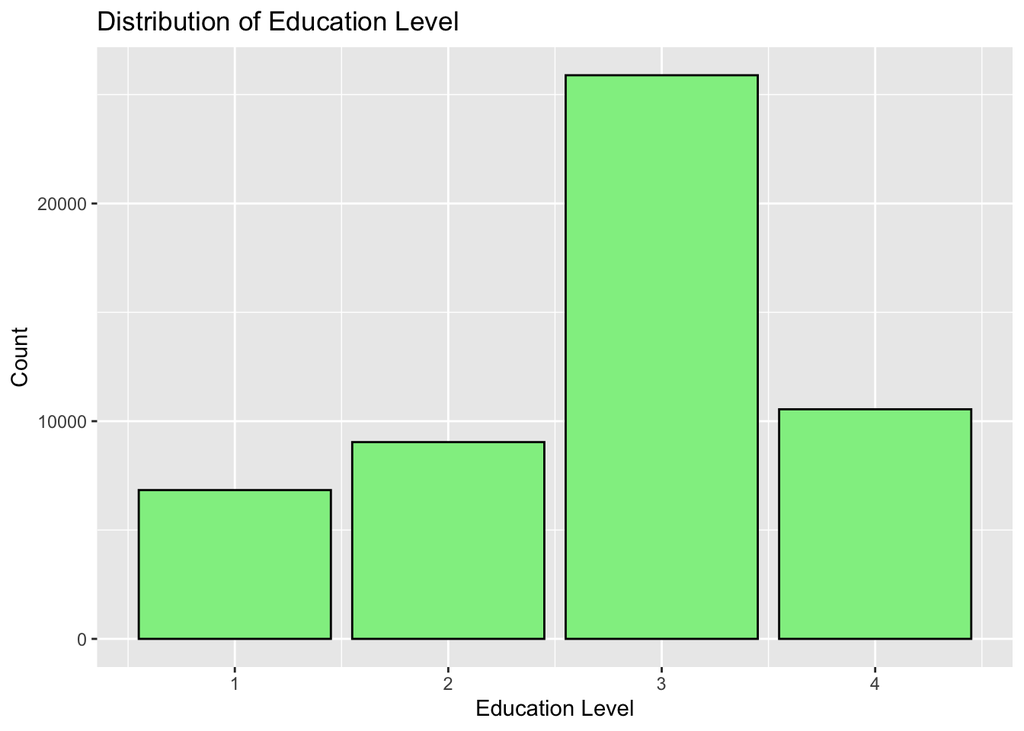

   ```r
   #type of your code/command here.

   # Bar Plot for Education Level
     ggplot(data = subset(ess_polity, !is.na(edu)), aes(x=edu))  + # We need to remove the NA values
     geom_bar(fill = "lightgreen", color = "black") +
     labs(title = "Distribution of Education Level", x = "Education Level", y = "Count")
   ```

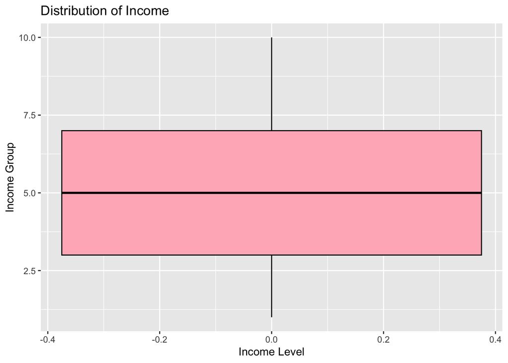

   ```r
     # Box Plot for income_10
     ggplot(ess_polity, aes(y = income_10)) +
     geom_boxplot(fill = "lightpink", color = "black") +
     labs(title = "Distribution of Income", y = "Income Group", x = "Income Level")
   ```

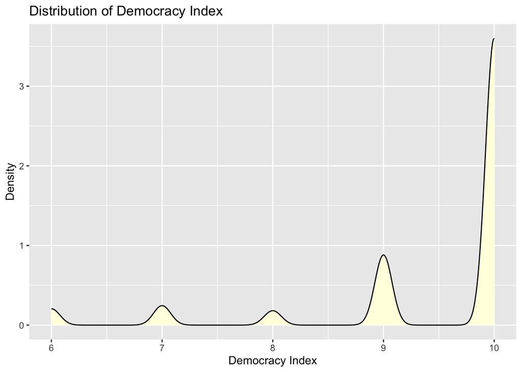

   ```r
     # Density Plot for Democracy Index
     ggplot(data = ess_polity, aes(x = democ)) +
     geom_density(fill = "lightyellow", color = "black") +
     labs(title = "Distribution of Democracy Index", x = "Democracy Index", y = "Density")
   ```

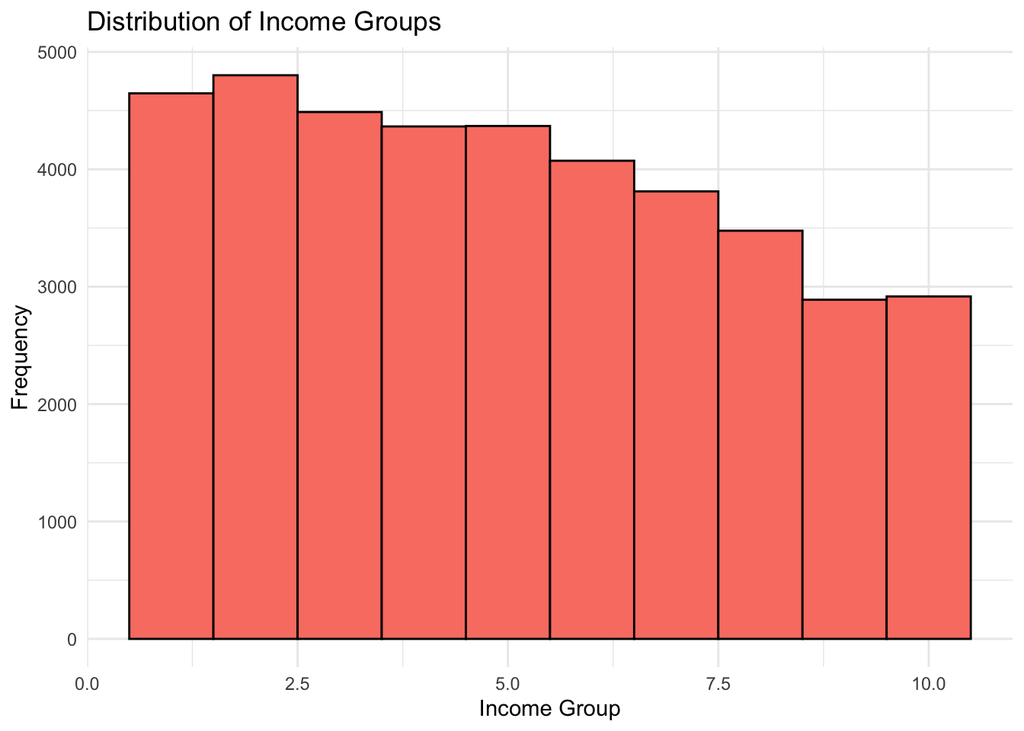

   ```r
     # Histogram for Income Groups
     ggplot(data = ess_polity, aes(x = income_10)) +
     geom_histogram(binwidth = 1, fill = "salmon", color = "black") +
     labs(title = "Distribution of Income Groups", x = "Income Group", y = "Frequency") +
     theme_minimal()
   ```

   I use a Bar plot to plot *education level* as it a ordinal variable.

   I use a boxplot to plot *income_10* as it is a numerical data and also boxplot is suitable for displaying the distribution of identifying outliers, which is useful for understanding income distribution.

   I use a Density plot to plot *democracy index* as it is a continuous numeric variables.

   I use a Histogram to plot *income groups* as it shows the distribution of income levels across different groups.
3. **Suppose we want to test two hypotheses on the relationships of two pairs of variables**. **Please use the appropriate type of graphs we learned to visualize these two pairs of variables. Briefly describe the graph you plot, and answer: Does the graph we create from the data support the hypothesis?**

   (1) Hypothesis#1: The more years of education (edu) a person completed, the higher income (income_10) they earn.

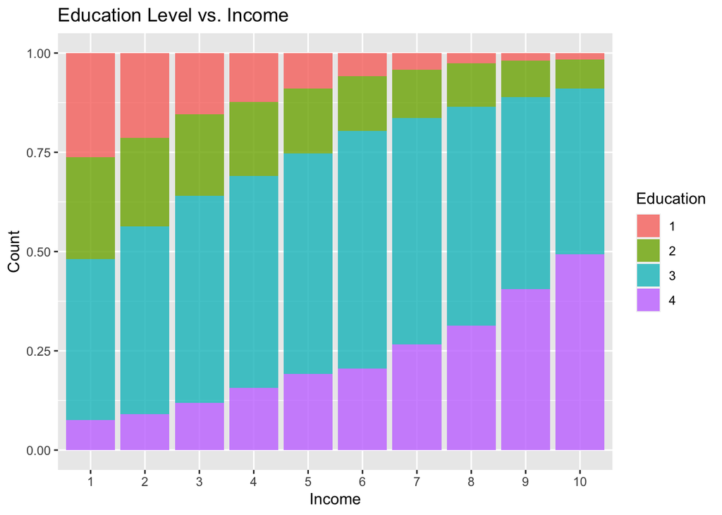

   ```r
   # Scatter plot for Edu vs. Income_10
   ess_polity|>
   subset(!is.na(income_10))|>
   subset(!is.na(edu))|>
   ggplot(aes(x = as.factor(income_10), fill = as.factor(edu))) +
   geom_bar( position="fill", alpha = 0.8) +
   labs(title = "Education Level vs. Income", x = "Income", y = "Count") +
   scale_fill_discrete(name = "Education")
   ```

   The graph illustrating hypothesis 1 utilizes a stacked percentage bar chart to analyze the correlation between education level and income, displaying their aggregate values. This visualization method enables the observation of potential patterns or trends in these variables. Notably, it shows an increase in the proportion of individuals with the highest education level (4) within higher income groups. Therefore, based on the graph, our hypothesis appears to be valid.

   (2) Hypothesis#2: There is a gender disparity (male) in voting behavior (vote). (Either men are more likely to vote, or women are more likely to vote).

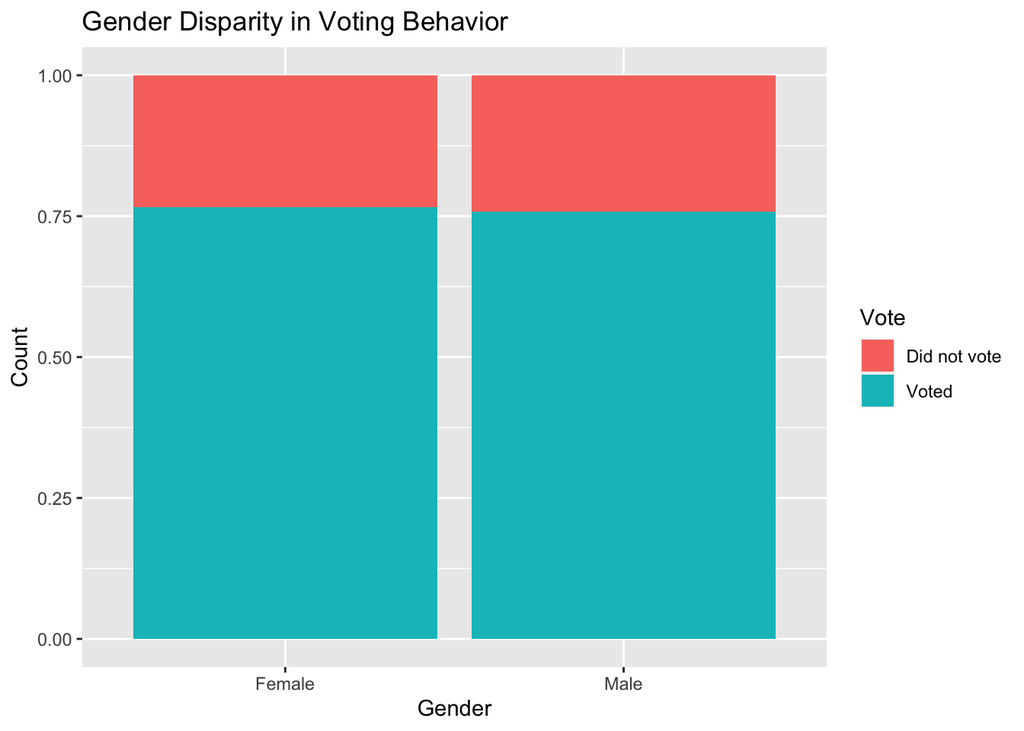

   ```r
   #type of your code/command here.
   ess_polity|>
   subset(!is.na(male))|>
   subset(!is.na(vote))|>
   ggplot(aes(x = as.factor(male), fill = as.factor(vote))) +
   geom_bar(position = "fill") +
   labs(title = "Gender Disparity in Voting Behavior", x = "Gender", y = "Count") +
   scale_x_discrete(labels = c("Female", "Male")) +
   scale_fill_discrete(name = "Vote", labels = c("Did not vote", "Voted"))
   ```

   ```r
   ess_polity|>
   group_by(male)|>
   subset(!is.na(male))|>
   subset(!is.na(vote))|>
   summarise(mean(vote))
   ```

   | male | mean(vote) |
   | --- | --- |
   | 0 | 0.7667045 |
   | 1 | 0.7585367 |

## Part 2. Comparing between Partial and Whole, and among Groups

In this part, we will use the clean version of the Australian public opinion poll on Same-Sex Marriage to generate graphs and plots. **You may need to do the data transformation or mutation needed to help graphing.**

1. Read in data.

   ```r
   #type of your code/command here.
   australian_data <- read.csv("australian_data.csv")
   head(australian_data, 5)
   ```

   |  | X | District | Yes | No | Illegible | No.Response | Division |
   | --- | --- | --- | --- | --- | --- | --- | --- |
   | 1 | 1 | Banks | 37736 | 46343 | 247 | 20928 | New South Wales Divisions |
   | 2 | 2 | Barton | 37153 | 47984 | 226 | 24008 | New South Wales Divisions |
   | 3 | 3 | Bennelong | 42943 | 43215 | 244 | 19973 | New South Wales Divisions |
   | 4 | 4 | Berowra | 48471 | 40369 | 212 | 16038 | New South Wales Divisions |
   | 5 | 5 | Blaxland | 20406 | 57926 | 220 | 25883 | New South Wales Divisions |

2. Use a barplot to graph the Australian data based on their responses: yes, no, illegible, and no response. The y-axis should be the count of responses, and each response should be represented by one individual bar (so there should be four bars).

   (you can use either geom_bar() or geom_col())

   ```r
   tidy_australian_data <- australian_data %>%
     pivot_longer(cols = -c(X, District, Division), names_to = "Response", values_to = "Count")

   head(tidy_australian_data, 5)
   ```

   | X | District | Division | Response | Count |
   | --- | --- | --- | --- | --- |
   | 1 | Banks | New South Wales Divisions | Yes | 37736 |
   | 1 | Banks | New South Wales Divisions | No | 46343 |
   | 1 | Banks | New South Wales Divisions | Illegible | 247 |
   | 1 | Banks | New South Wales Divisions | No.Response | 20928 |
   | 2 | Barton | New South Wales Divisions | Yes | 37153 |

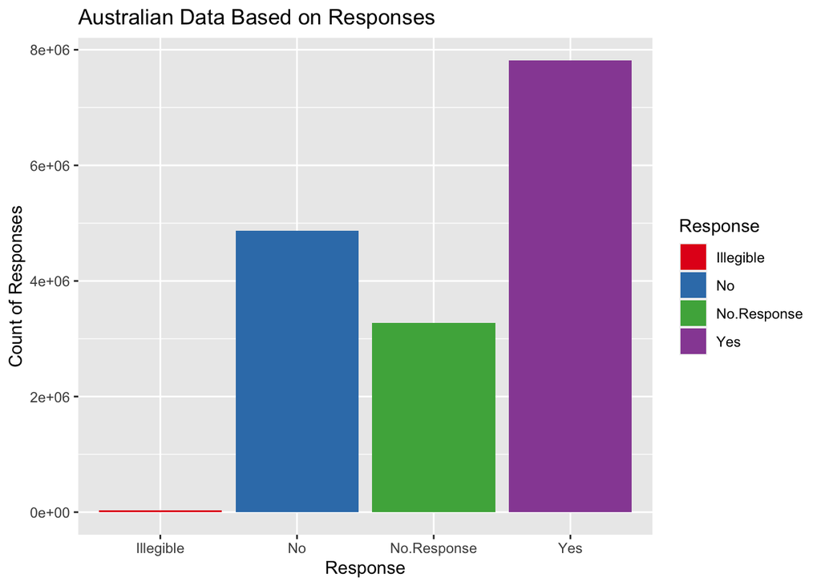

   ```r
   tidy_australian_data_count <- tidy_australian_data %>%
     group_by(Response) %>%
     summarize(Count = sum(Count, na.rm = TRUE))

   ggplot(tidy_australian_data_count, aes(x = Response, y = Count, fill = Response)) +
     geom_col() +
     labs(title = "Australian Data Based on Responses", x = "Response", y = "Count of Responses") +
     scale_fill_brewer(palette = "Set1")
   ```

3. The previous graph only shows the difference in amount. Let’s create a stacked-to-100% barplot to show the proportion of each of the four responses (by % of the total response).

   (you can use either geom_bar() or geom_col())

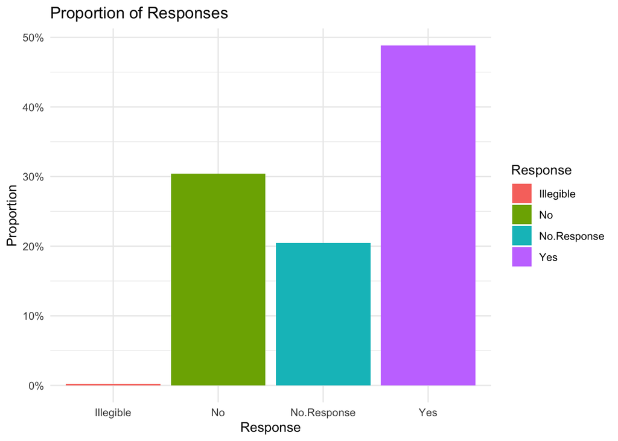

   ```r
   prop <- data.frame(Response = tidy_australian_data_count$Response, Count = tidy_australian_data_count$Count)

   tidy_australian_data_prop <- tidyr::gather(prop, key="Response", value="Count") %>%
                           transform(prop, Proportion = Count / sum(Count))

   ggplot(tidy_australian_data_prop, aes(x=Response, y=Proportion, fill=Response)) +
     geom_bar(stat="identity") +
     labs(title="Proportion of Responses",
      x="Response",
      y="Proportion") +
     scale_y_continuous(labels=scales::percent_format()) +
     theme_minimal()
   ```

4. Let’s see if there’s a relationship between Division and Response - that is, are certain divisions more likely to respond one way compared to other divisions? Again, we will use barplot(s) to present the visualization.

   (you can use either geom_bar() or geom_col())

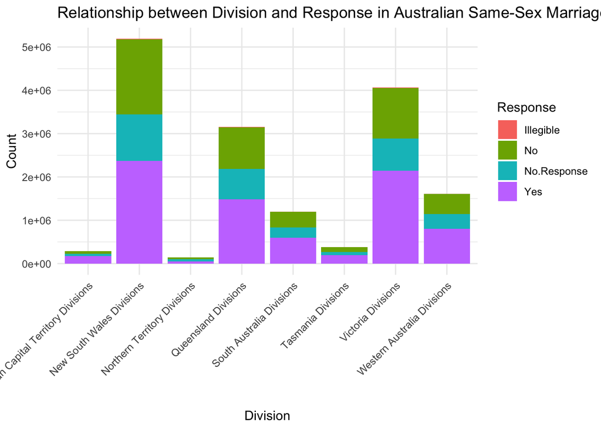

   ```r
   #type of your code/command here.
   ggplot(tidy_australian_data, aes(x = Division, y = Count, fill = Response)) +
       geom_bar(stat = "identity") +
       xlab("Division") +
       ylab("Count") +
       ggtitle("Relationship between Division and Response in Australian Same-Sex Marriage Poll") +
       theme_minimal() +
       theme(axis.text.x = element_text(angle = 45, hjust = 1))
   ```

## Part 3. Practice plotting with a dataset of your choice

In this part, you will choose data of your interests for graphing and plotting. This data can be tidy/ready-to-be-used or raw data that needs cleaning. If the data is very large (for example, more than 20 columns), you should definitely subset the data by selecting less than 10 variables of your interests to avoid taking too much room in your R memory.

1. Include a link to the data page (this page should include the introduction or description and the link to download this dataset).

For this task, I’ll choose a dataset from the UCI Machine Learning Repository focusing on student achievement in secondary education from two Portuguese schools. This dataset includes student grades and various socio-demographic features collected through school reports and questionnaires. Specifically, we’ll analyze student performance in the mathematics subject. You can access the dataset via this link: https://archive.ics.uci.edu/dataset/320/student+performance

2. Read the data you choose and briefly answer the following questions. (Optional: you may need to subset, clean, and transform the data if necessary).

   ```r
   #type of your code/command here.
   student_data <- read.csv("student-mat.csv", header = TRUE, sep = ";")
   head(student_data)
   ```

   |  | school | sex | age | address | famsize | Pstatus | Medu | Fedu | Mjob | Fjob | reason | guardian | traveltime | studytime | failures | schoolsup | famsup | paid | activities | nursery | higher | internet | romantic | famrel | freetime | goout | Dalc | Walc | health | … |
   | --- | --- | --- | --- | --- | --- | --- | --- | --- | --- | --- | --- | --- | --- | --- | --- | --- | --- | --- | --- | --- | --- | --- | --- | --- | --- | --- | --- | --- | --- | --- |
   | 1 | GP | F | 18 | U | GT3 | A | 4 | 4 | at_home | teacher | course | mother | 2 | 2 | 0 | yes | no | no | no | yes | yes | no | no | 4 | 3 | 4 | 1 | 1 | 3 | … |
   | 2 | GP | F | 17 | U | GT3 | T | 1 | 1 | at_home | other | course | father | 1 | 2 | 0 | no | yes | no | no | no | yes | yes | no | 5 | 3 | 3 | 1 | 1 | 3 | … |
   | 3 | GP | F | 15 | U | LE3 | T | 1 | 1 | at_home | other | other | mother | 1 | 2 | 3 | yes | no | yes | no | yes | yes | yes | no | 4 | 3 | 2 | 2 | 3 | 3 | … |
   | 4 | GP | F | 15 | U | GT3 | T | 4 | 2 | health | services | home | mother | 1 | 3 | 0 | no | yes | yes | yes | yes | yes | yes | yes | 3 | 2 | 2 | 1 | 1 | 5 | … |
   | 5 | GP | F | 16 | U | GT3 | T | 3 | 3 | other | other | home | father | 1 | 2 | 0 | no | yes | yes | no | yes | yes | no | no | 4 | 3 | 2 | 1 | 2 | 5 | … |
   | 6 | GP | M | 16 | U | LE3 | T | 4 | 3 | services | other | reputation | mother | 1 | 2 | 0 | no | yes | yes | yes | yes | yes | yes | no | 5 | 4 | 2 | 1 | 2 | 5 | … |

As, we have more than 20 columns, we will focus on specific columns of interest from the dataset, including school (binary: ‘GP’ or ‘MS’), sex (binary: ‘F’ or ‘M’), age (numeric: 15 to 22), activities (binary: yes or no), health (numeric: 1 to 5), freetime (numeric: 1 to 5), absences (numeric: 0 to 93), G1 (numeric: 0 to 20), G2 (numeric: 0 to 20), and G3 (numeric: 0 to 20, output target).

```
\(1\) What is the structure (dimension) of the data;
```

```r
    student_data <- select(student_data, school, sex, age, activities, health, freetime, absences, G1, G2, G3)
    head(student_data,5)
```

|  | school | sex | age | activities | health | freetime | absences | G1 | G2 | G3 |
| --- | --- | --- | --- | --- | --- | --- | --- | --- | --- | --- |
| 1 | GP | F | 18 | no | 3 | 3 | 6 | 5 | 6 | 6 |
| 2 | GP | F | 17 | no | 3 | 3 | 4 | 5 | 5 | 6 |
| 3 | GP | F | 15 | no | 3 | 3 | 10 | 7 | 8 | 10 |
| 4 | GP | F | 15 | yes | 5 | 2 | 2 | 15 | 14 | 15 |
| 5 | GP | F | 16 | no | 5 | 3 | 4 | 6 | 10 | 10 |

```r
    dim <- dim(student_data)
    print(paste('Rows = ', dim[1]))
```

```
[1] "Rows =  395"
```

```r
    print(paste('Columns = ', dim[2]))
```

```
[1] "Columns =  10"
```

```
\(2\) What is the unit of observation?

In this dataset, the unit of observation is a `student`.

\(3\) What does each column mean in this data?

Each column represents various attributes related to the students, such as age, sex, student activities, academic information, etc.
```

3. Choose two columns/variables of your interests. Plot one univariate graph for each of the variables.

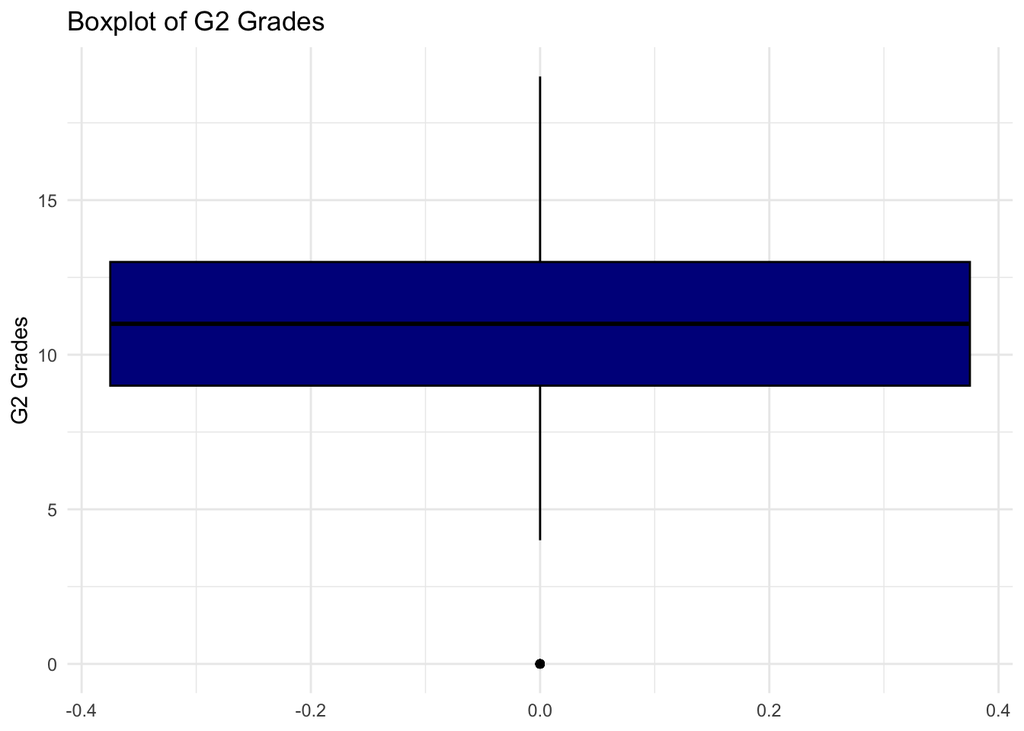

   ```r
   #type of your code/command here.

   ggplot(student_data, aes(y = G2)) +
   geom_boxplot(fill = "darkblue", color = "black") +
   labs(title = "Boxplot of G2 Grades", y = "G2 Grades") +
   theme_minimal()
   ```

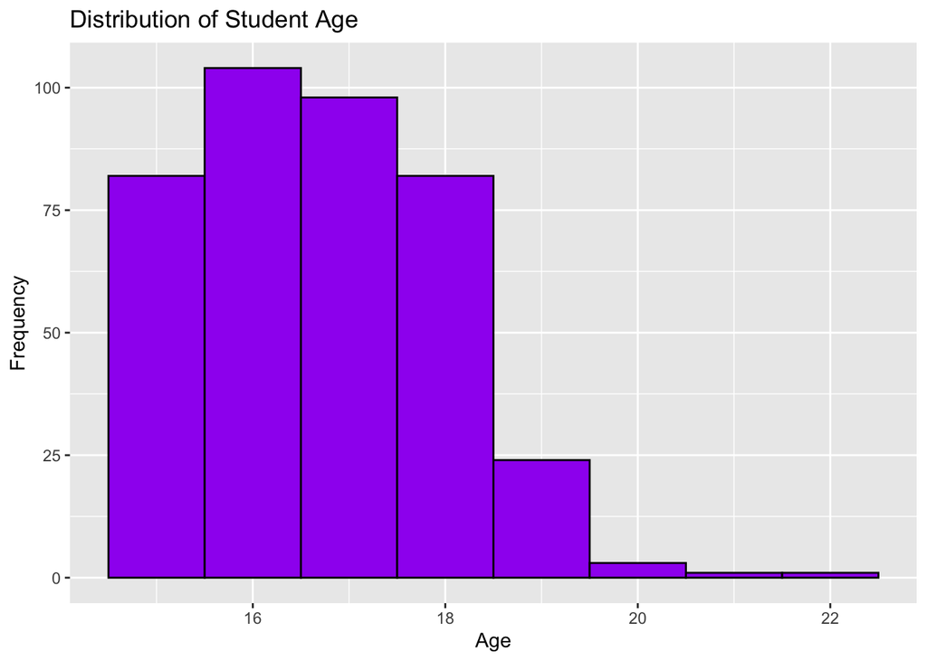

   ```r
   ggplot(student_data, aes(x = age)) +
   geom_histogram(binwidth = 1, fill = "purple", color = "black") +
   labs(title = "Distribution of Student Age", x = "Age", y = "Frequency")
   ```

4. Choose a pair of variables that may be correlated and make a graph (scatter plot or barplot) using them. Based on the visual evidence, do you see any potential correlation between the two variables

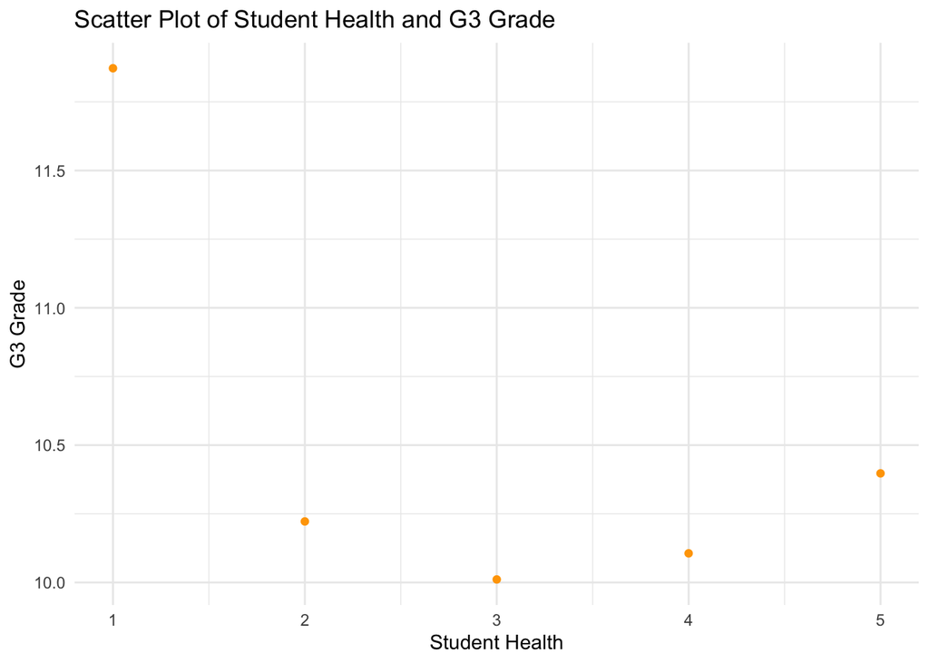

   ```r
   #type of your code/command here.
   summary <- aggregate(G3 ~ health, data=student_data, FUN=mean)

   ggplot(summary, aes(x = health, y = G3)) +
   geom_point(color = "orange") +
   labs(title = "Scatter Plot of Student Health and G3 Grade", x = "Student Health", y = "G3 Grade") +
   theme_minimal()
   ```

The better is student’s health (health), the higher overall grade (G3) they achieve.

`Relation:` The relationship observed in the aggregate scatter plot between overall grade (G3) and student health suggests a quadratic association. Specifically, when health is at its poorest, students tend to achieve the highest grades. As health improves to a normal level, overall grades decline, but they rise again as health reaches a very good level. This indicates that our initial hypothesis, assuming a linear relationship, is not entirely accurate. Further statistical tests are necessary to draw precise conclusions.

## Appendix: sources for data to be used in Part 3

**Here are some online sources and popular Online Dataset Hub:**

1. Many US governments (usually at the federal and state levels), bureaus, and departments have open data archives on their websites, allowing the public to access, download, and use them. Just use Google to search for them.
2. [**The Harvard Dataverse Repository**](https://dataverse.harvard.edu/) is a free data repository open to all researchers from any discipline, inside and outside the Harvard community, where you can share, archive, cite, access, and explore research data. Each individual Dataverse collection is a customizable collection of datasets (or a virtual repository) for organizing, managing, and showcasing datasets.
3. [**Inter-university Consortium for Political and Social Research (ICPSR)**](https://www.icpsr.umich.edu/web/pages/ICPSR/index.html) of the University of Michigan-Ann Arbor provides leadership and training in data access, curation, and methods of analysis for the social science research community.
4. **UN: https://data.un.org/**
5. [**OECD Data**](https://data.oecd.org/): economic and development data of the most developed countries in the world.
6. The five sources above are mainly for social science data; **there exists another very big community and open data archives for machine-learning and data science: [Kaggle](https://www.kaggle.com/datasets).**